# Module 5: Microbial Interactions

MB 360: Scientific Inquiry in Microbiology At the Bench

Carlos C. Goller, Ph.D.

NC State University | Department of Biological Sciences

Camila Loyola, Graduate Teaching Assistant

2026-09-08

## Module 5: Microbial Interactions

MB 360: Scientific Inquiry in Microbiology At the Bench

MB 360 Lab Workbook  
NC State University | Department of Biological Sciences

## Overview

**Weeks 8–9** · Co-culture experiments · Diffusion-mediated contact · Growth data analysis

- Evaluate microbial interactions through co-culture of different isolates
- Observe growth while maintaining fluidic contact across a membrane
- Analyze inhibition or facilitation patterns

## Learning Outcomes

- **List** safety considerations for propagating microbes
- **Explain** the purpose of Duet wells and co-culture assays
- **Discuss** the significance of microbial fluid interactions
- **Practice** diluting cultures to a target value
- **Seed** wells consistently without contamination
- **Collect** and **interpret** co-culture growth data
- **Revise** the draft for the individual and group projects

## Skills & Knowledge

Skills

- Follow lab safety and PPE protocols
- Use Cerillo vertical membrane co-culture systems correctly
- Analyze co-culture growth data

Knowledge

- PPE requirements for microbial work
- Co-culture design and growth assessment
- Microbial interaction concepts

## Background: Cerillo Duet System

Adjacent chambers separated by a **membrane** allow exchange of metabolites without direct mixing of cells.

Questions this module addresses:

- Does *Delftia acidovorans* SPH-1 support, suppress, or reshape your isolate’s growth?
- What metabolites or resources might explain the observed pattern?

## Lab Safety

- Wear required PPE; clean benches and pipettors with 70% ethanol
- Treat all tips as biohazards
- Decontaminate liquids, glass, and work surfaces after lab

## Methods: Day of the Lab

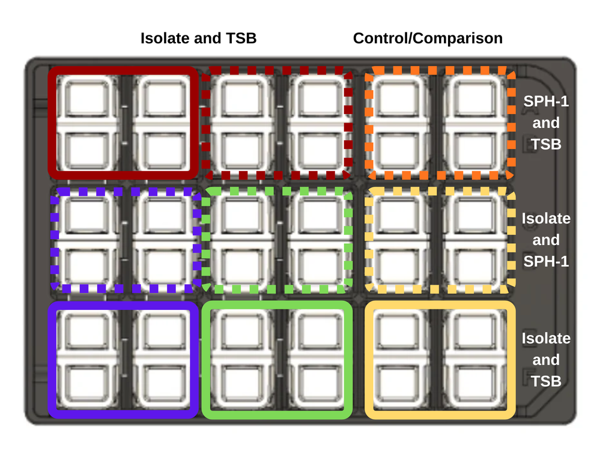

Cerillo Duet co-culture layout with isolate-only, control, and co-culture conditions.

1. Dilute overnight culture 1:1000 into fresh TSB
2. Add 800 µL diluted culture to triplicate isolate-only wells
3. Add 800 µL diluted *Delftia* SPH-1 to triplicate co-culture wells
4. Add 800 µL fresh TSB to triplicate negative-control wells
5. Assemble Duet inserts; seat them securely in the co-culture wells
6. Seal the plate with a breathable membrane seal
7. Load into the plate reader at **30 °C** with continuous shaking; read **OD600** every 30 min for **48 h**

## Results & Discussion

- Export raw OD600 readings and apply blank correction
- Plot growth curves for isolate-only, SPH-1-only, and co-culture conditions
- Identify whether the interaction is neutral, mutualistic, or inhibitory
- Connect the observed pattern to possible metabolite exchange or competition

## Reflection Questions

1. What is the purpose of the membrane in the Cerillo Duet system?
2. How would you distinguish a mutualistic interaction from a commensal one in these data?
3. What follow-up experiment would you design to test your hypothesis about the interaction?